# Coursera Practical Machine Learning - Predicting Exercising Manner

SynnWy

February 22, 2017

## Overview

This project is about predicting users’ exercising manner, in order to review the statistics of how well a person is performing in the activity. In order to explore such studies, we used data sets provided by http://groupware.les.inf.puc-rio.br/har (weight lifting exercise dataset) which consists of data collected from 6 participants’ accelerometer readings. Readings are taken down as they performed barbell lifts in 5 different ways, both correct and incorrect methods.

### Data

As mentioned above, the 5 ways are:

1. Class A: according to instructions. [Correct]
2. Class B: throwing the elbows to the front. [Incorrect]
3. Class C: lifting the dumbell only halfway. [Incorrect]
4. Class D: lowering the dumbell only halfway.[Incorrect]
5. Class E: throwing the hips to the front. [Incorrect]

## Data Processing

#### Load data & R packages needed

```r
# load packages
library(caret)
library(rattle)
library(rpart)
library(rpart.plot)
library(randomForest)
library(repmis)

url.training <- "https://d396qusza40orc.cloudfront.net/predmachlearn/pml-training.csv"
url.testing <- "https://d396qusza40orc.cloudfront.net/predmachlearn/pml-testing.csv"

# load data
setwd("D:\\WY\\DataScience\\Practical_MachineLearning\\Coursera-Practical-Machine-Learning")

if (!file.exists("training.csv")) {
    download.file(url.training, destfile = "training.csv")
}

if (!file.exists("testing.csv")) {
    download.file(url.testing, destfile = "testing.csv")
}

training <- read.csv("training.csv", na.strings = c("NA", ""),
    stringsAsFactors = FALSE)
testing <- read.csv("testing.csv", na.strings = c("NA", ""),
    stringsAsFactors = FALSE)

# partition training data
ptraining <- createDataPartition(y = training$classe, p = 0.7,
    list = F)
ptraining1 <- training[ptraining, ]
ptrainingv <- training[-ptraining, ]

dim(ptraining1)
```

```
## [1] 13737   160
```

```r
dim(ptrainingv)
```

```
## [1] 5885  160
```

## Data Cleaning

```r
# remove variables that are near to zero variance
nearZero <- nearZeroVar(ptraining1)
ptraining1 <- ptraining1[, -nearZero]
ptrainingv <- ptrainingv[, -nearZero]

# remove NA
ptrainNA <- sapply(ptraining1, function(x) mean(is.na(x))) >
    0.95
ptraining1 <- ptraining1[, ptrainNA == F]
ptrainingv <- ptrainingv[, ptrainNA == F]

# remove unwanted columns (X, user_name,
# raw_timestamp_part_1, raw_timestamp_part_2, cvtd_timestamp)
ptraining1 <- ptraining1[, -(1:5)]
```

## Prediction Algorithms

#### Classification Trees

In order to save time, we used 5-fold cross validation in this algorithm implementation.

```r
cvControl <- trainControl(method = "cv", number = 5)
rpartpt <- train(classe ~ ., data = ptraining1, method = "rpart",
    trControl = cvControl)
print(rpartpt, digits = 4)
```

```
## CART
##
## 13737 samples
##    53 predictor
##     5 classes: 'A', 'B', 'C', 'D', 'E'
##
## No pre-processing
## Resampling: Cross-Validated (5 fold)
## Summary of sample sizes: 10989, 10990, 10990, 10989, 10990
## Resampling results across tuning parameters:
##
##   cp       Accuracy  Kappa
##   0.03911  0.5476    0.42065
##   0.06029  0.3917    0.16768
##   0.11576  0.3333    0.07466
##
## Accuracy was used to select the optimal model using  the largest value.
## The final value used for the model was cp = 0.03911.
```

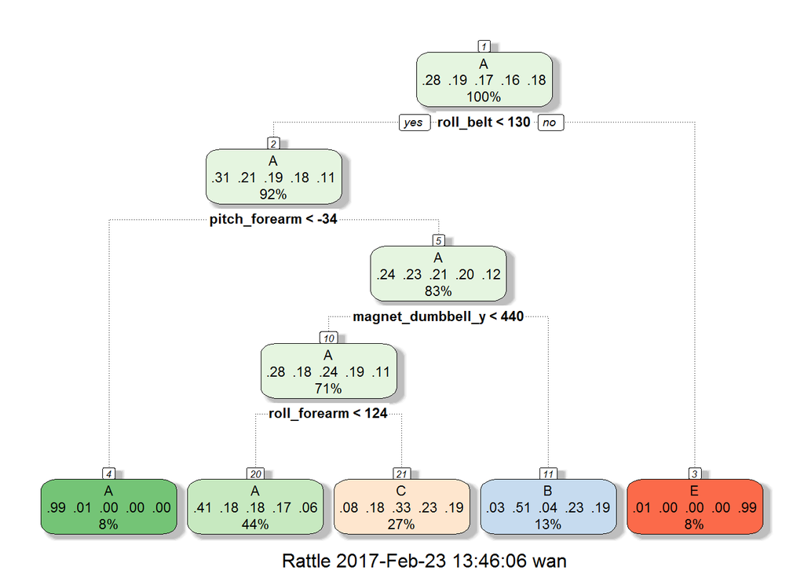

```r
fancyRpartPlot(rpartpt$finalModel)
```

```r
# prediction with ptrainingv (validation)
predictptv <- predict(rpartpt, ptrainingv)
(cmptv <- confusionMatrix(ptrainingv$classe, predictptv))
```

```
## Confusion Matrix and Statistics
##
##           Reference
## Prediction    A    B    C    D    E
##          A 1525   25  121    0    3
##          B  482  384  273    0    0
##          C  477   40  509    0    0
##          D  440  158  366    0    0
##          E  157  158  285    0  482
##
## Overall Statistics
##
##                Accuracy : 0.4928
##                  95% CI : (0.4799, 0.5056)
##     No Information Rate : 0.5235
##     P-Value [Acc > NIR] : 1
##
##                   Kappa : 0.3367
##  Mcnemar's Test P-Value : NA
##
## Statistics by Class:
##
##                      Class: A Class: B Class: C Class: D Class: E
## Sensitivity            0.4950  0.50196  0.32754       NA  0.99381
## Specificity            0.9469  0.85254  0.88063   0.8362  0.88889
## Pos Pred Value         0.9110  0.33714  0.49610       NA  0.44547
## Neg Pred Value         0.6305  0.91972  0.78494       NA  0.99938
## Prevalence             0.5235  0.12999  0.26406   0.0000  0.08241
## Detection Rate         0.2591  0.06525  0.08649   0.0000  0.08190
## Detection Prevalence   0.2845  0.19354  0.17434   0.1638  0.18386
## Balanced Accuracy      0.7209  0.67725  0.60408       NA  0.94135
```

```r
(rpartacc <- cmptv$overall[1])
```

```
##  Accuracy
## 0.4927782
```

As seen above, the accuracy rate is 0.5 and thus the out-of-sample error rate is 0.5 too. However, this algorithm did not predict the outcome classe very well.

#### Random Forest

```r
rftraining <- train(classe ~ ., data = ptraining1, method = "rf",
    trControl = cvControl)
print(rftraining, digits = 4)
```

```
## Random Forest
##
## 13737 samples
##    53 predictor
##     5 classes: 'A', 'B', 'C', 'D', 'E'
##
## No pre-processing
## Resampling: Cross-Validated (5 fold)
## Summary of sample sizes: 10991, 10987, 10990, 10989, 10991
## Resampling results across tuning parameters:
##
##   mtry  Accuracy  Kappa
##    2    0.9937    0.9920
##   27    0.9970    0.9962
##   53    0.9948    0.9935
##
## Accuracy was used to select the optimal model using  the largest value.
## The final value used for the model was mtry = 27.
```

```r
# prediction with ptrainingv (validation)
predictrft <- predict(rftraining, ptrainingv)
(cmrft <- confusionMatrix(ptrainingv$classe, predictrft))
```

```
## Confusion Matrix and Statistics
##
##           Reference
## Prediction    A    B    C    D    E
##          A 1674    0    0    0    0
##          B    2 1137    0    0    0
##          C    0    1 1025    0    0
##          D    0    0    2  961    1
##          E    0    0    0    3 1079
##
## Overall Statistics
##
##                Accuracy : 0.9985
##                  95% CI : (0.9971, 0.9993)
##     No Information Rate : 0.2848
##     P-Value [Acc > NIR] : < 2.2e-16
##
##                   Kappa : 0.9981
##  Mcnemar's Test P-Value : NA
##
## Statistics by Class:
##
##                      Class: A Class: B Class: C Class: D Class: E
## Sensitivity            0.9988   0.9991   0.9981   0.9969   0.9991
## Specificity            1.0000   0.9996   0.9998   0.9994   0.9994
## Pos Pred Value         1.0000   0.9982   0.9990   0.9969   0.9972
## Neg Pred Value         0.9995   0.9998   0.9996   0.9994   0.9998
## Prevalence             0.2848   0.1934   0.1745   0.1638   0.1835
## Detection Rate         0.2845   0.1932   0.1742   0.1633   0.1833
## Detection Prevalence   0.2845   0.1935   0.1743   0.1638   0.1839
## Balanced Accuracy      0.9994   0.9993   0.9989   0.9981   0.9992
```

```r
(rfacc <- cmrft$overall[1])
```

```
##  Accuracy
## 0.9984707
```

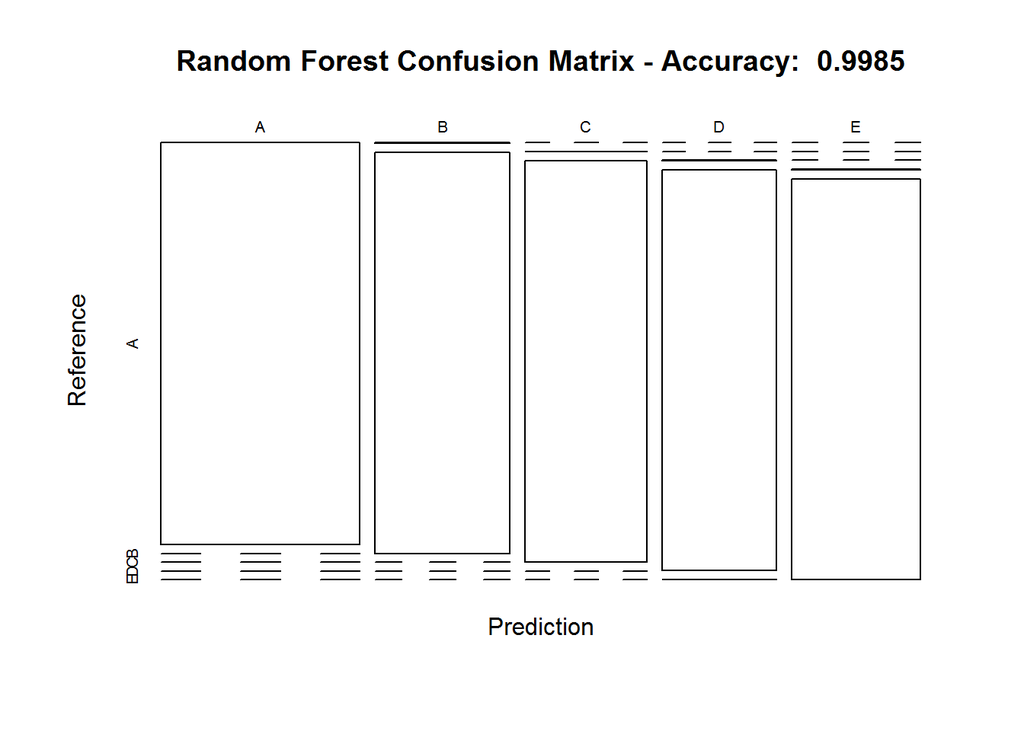

```r
plot(cmrft$table, col = cmptv$byClass, main = paste("Random Forest Confusion Matrix - Accuracy: ",
    round(cmrft$overall["Accuracy"], 4)))
```

With this algorithm, the output is much better as you can see above, the accuracy rate is 0.998 whereas the out-of-sample error rate is 0.002. One of the reason could be the high correlation among predictors and random forests chooses a subset of predictors at each split and then decorrelate the trees. By doing this, we could obtain high accuract results however, nothing is perfect, this algorithm can be difficult to interpret and computationally inefficient at times.

## Predicting Results on Test Data

Random Forest gave us the higher accuracy compared to classification trees, which is 99.8%. The out-of-sample error rate is 100 - 99.8 = 0.2%.

```r
(predict(rftraining, testing))
```

```
##  [1] B A B A A E D B A A B C B A E E A B B B
## Levels: A B C D E
```